# Portfolio Investment Assignment

Group Project Q3

Yang Dun, Ge Weitong, Li Zichang, Wu Hongsheng, Xiang ZiShun

# Overview

- SPDR sector ETFs: `c('XLB','XLE','XLF','XLI','XLK','XLP','XLU','XLV','XLY')` and `'SPY'`
- History from 1999-11-01 to now.
- Strategy: 5 kinds
  - Equal-weighted with 1) no re-balance, 2) monthly re-balance, 3) annual re-balance
  - Momentum strategy with 1) long top 4, 2) long top 2 and short bottom 2
- Note:
  - All equity position, no cash.
  - Do not load other library, use only the listed packages here.
  - Submit Rmd and Rda data files together in a compressed file (.zip, .7z, etc.)
- Disclaimer: this is no an investment advise.

## Download

```r
# Change (FALSE) to (TRUE), when you need to download data.
# Usually you only need to run this once.
# Change file location

# 'XLC', 'XLRE' has shorter history, don't use them.
all_tickers <- c('XLB','XLE','XLF','XLI','XLK','XLP','XLU','XLV','XLY','SPY')

if (FALSE) {
  av_api_key("1E8IOHPTPNIQE4IY")

  for (tt in all_tickers) {
    df_xlc <- av_get(tt, av_fun = "TIME_SERIES_DAILY_ADJUSTED", outputsize="full")
    saveRDS(df_xlc, paste0(wd, "/" ,tt,".Rds"))
    cat(paste(tt,min(df_xlc$timestamp),max(df_xlc$timestamp),"\n"))
  }
}
```

```r
all_tickers <- c('XLB','XLE','XLF','XLI','XLK','XLP','XLU','XLV','XLY','SPY')
# make sure all starts from the same time and same length.
dd <- list()
for (tt in all_tickers) {
  dd[[tt]] <- readRDS(paste0(wd, "/" ,tt,".Rds"))
  print(paste(tt, min(dd[[tt]]$timestamp), nrow(dd[[tt]])))
  assert(min(dd[[tt]]$timestamp) == as.Date('1999-11-01'))
  assign(paste0('df_',tolower(tt)), dd[[tt]], envir = .GlobalEnv)
}
```

```
## [1] "XLB 1999-11-01 5278"
## [1] "XLE 1999-11-01 5278"
## [1] "XLF 1999-11-01 5278"
## [1] "XLI 1999-11-01 5278"
## [1] "XLK 1999-11-01 5278"
## [1] "XLP 1999-11-01 5278"
## [1] "XLU 1999-11-01 5278"
## [1] "XLV 1999-11-01 5278"
## [1] "XLY 1999-11-01 5278"
## [1] "SPY 1999-11-01 5278"
```

### Technology vs. Energy

- Energy was the rock star during 90s and 00s, abruptly stopped during GFC on the journey towards $200/bbl (never there).
- Technology was a prodigy from late 70s, stumbled in early 00s, but now a rock star.

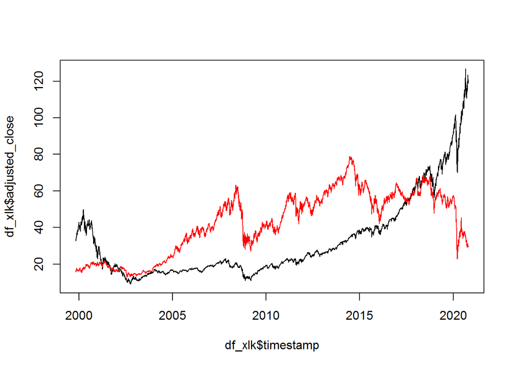

```r
plot(df_xlk$timestamp, df_xlk$adjusted_close,type='l')
points(df_xle$timestamp, df_xle$adjusted_close,col='red',type='l')
```

# Equal-weighted Strategy

## Compute daily return series

```r
len_tickers <- length(all_tickers)
ii <- 1
daily_ret <- tail(tibble(Date = dd[[1]]$timestamp), -1)
for (ii in 1:len_tickers) {
  daily_ret[all_tickers[ii]] <- tail(dd[[ii]]$adjusted_close / lag(dd[[ii]]$adjusted_close, 1)-1,-1)
}
for (ii in 1:len_tickers) {
  daily_ret[paste0(all_tickers[ii],"_cumret")] <- cumprod(1 + daily_ret[all_tickers[ii]])
}
```

## Performance

Firstly, we set the rebalance dates for monthly and yearly strategies

```r
calc_rebal_days <- function(nn, period) {
  rev(nn - (0:(round(nn / period, 0) - 1)) * period)
}

# Monthly re-balance
# every 21 days
rebal_days_m <- calc_rebal_days(length(dd[[1]]$timestamp), 21)
head(rebal_days_m)
```

```
## [1]  28  49  70  91 112 133
```

```r
# Annual re-balance
# every 252 days
rebal_days_y <- calc_rebal_days(length(dd[[1]]$timestamp), 252)
head(rebal_days_y)
```

```
## [1]  238  490  742  994 1246 1498
```

```r
all_adj_price <- tibble(Date = dd[[1]]$timestamp)
for (ii in 1:len_tickers) {
  all_adj_price[all_tickers[ii]] <- dd[[ii]]$adjusted_close
}
```

## Calculate Strategy return

```r
# daily re-balance
invest_tickers <- all_tickers[all_tickers != 'SPY']
len_invest <- length(invest_tickers)
w <- rep(1, len_invest) / len_invest

daily_ret['EW'] <- as.matrix(daily_ret[,2:(2+len_invest-1)]) %*% w
```

```r
# no re-balance
no_rb <- daily_ret[c(1, 12:21)]
no_rb["EW_no_rb"] <- apply(no_rb[2:10], 1, mean)
s1 <- lag(no_rb["EW_no_rb"])
s1[1, 1] <- 1
no_rb["EW_no_rb_daily"] <- no_rb["EW_no_rb"] / s1 - 1

# Method2: consider total value of portfolio, initial invest 9 * 1000000
no_rb_2 <- all_adj_price
for (ii in 1:len_tickers) {
  no_rb_2[paste0(all_tickers[ii],"_num")] <- round(1000000 / (no_rb_2[all_tickers[ii]]))
}
no_rb_2[,12:20] <- no_rb_2[1,12:20]
no_rb_2[,21] <- round(9000000 / no_rb_2[1,11])
for (ii in 1:len_tickers) {
  no_rb_2[paste0(all_tickers[ii],"_mv")] <- no_rb_2[all_tickers[ii]] * no_rb_2[paste0(all_tickers[ii],"_num")]
}
no_rb_2["EW_mv"] <- apply(no_rb_2[22:30], 1, sum)
```

```r
# monthly re-balance
m_rb <- no_rb_2

for(i in 1:length(rebal_days_m)){
  if(i < length(rebal_days_m)){
  # mean of the total value
  m_rb[rebal_days_m[i], 22:30] <- m_rb[rebal_days_m[i], 32] / 9

  # allocate the new number of shares at re-balance date
  m_rb[rebal_days_m[i], 12:20] <- round(m_rb[rebal_days_m[i], 22:30] / m_rb[rebal_days_m[i], 2:10])

  # the number of shares in new period
  m_rb[(rebal_days_m[i]+1):(rebal_days_m[i+1]), 12:20] <- m_rb[rebal_days_m[i], 12:20]

  # calculate the new value in that period
  m_rb[(rebal_days_m[i]+1):(rebal_days_m[i+1]), 22:30] <- m_rb[(rebal_days_m[i]+1):(rebal_days_m[i+1]), 2:10] * m_rb[(rebal_days_m[i]+1):(rebal_days_m[i+1]), 12:20]

  m_rb[(rebal_days_m[i]+1):(rebal_days_m[i+1]), 32] <- apply(m_rb[(rebal_days_m[i]+1):(rebal_days_m[i+1]), 22:30], 1, sum)
  }

    else{
    m_rb[rebal_days_m[i], 22:30] <- m_rb[rebal_days_m[i], 32] / 9

    m_rb[rebal_days_m[i], 12:20] <- round(m_rb[rebal_days_m[i], 22:30] / m_rb[rebal_days_m[i], 2:10])
  }
}
```

```r
# yearly re-balance
y_rb <- no_rb_2

for(i in 1:length(rebal_days_y)){
  if(i < length(rebal_days_y)){
  # mean of the total value
  y_rb[rebal_days_y[i], 22:30] <- y_rb[rebal_days_y[i], 32] / 9

  # allocate the new number of shares at re-balance date
  y_rb[rebal_days_y[i], 12:20] <- round(y_rb[rebal_days_y[i], 22:30] / y_rb[rebal_days_y[i], 2:10])

  # the number of shares in new period
  y_rb[(rebal_days_y[i]+1):(rebal_days_y[i+1]), 12:20] <- y_rb[rebal_days_y[i], 12:20]

  # calculate the new value in that period
  y_rb[(rebal_days_y[i]+1):(rebal_days_y[i+1]), 22:30] <- y_rb[(rebal_days_y[i]+1):(rebal_days_y[i+1]), 2:10] * y_rb[(rebal_days_y[i]+1):(rebal_days_y[i+1]), 12:20]

  y_rb[(rebal_days_y[i]+1):(rebal_days_y[i+1]), 32] <- apply(y_rb[(rebal_days_y[i]+1):(rebal_days_y[i+1]), 22:30], 1, sum)
  }

    else{
    y_rb[rebal_days_y[i], 22:30] <- y_rb[rebal_days_y[i], 32] / 9

    y_rb[rebal_days_y[i], 12:20] <- round(y_rb[rebal_days_y[i], 22:30] / y_rb[rebal_days_y[i], 2:10])
  }
}
```

```r
# Final result
daily_ret['EW_cumret'] <- cumprod(daily_ret['EW'] + 1)
all_cumret <- m_rb[c(1, 32)][2:length(m_rb$Date), ]
colnames(all_cumret)[2] <- "EW_m_rb"
all_cumret[2] <- m_rb$EW_mv[2:length(m_rb$Date)] / 8999959
all_cumret <- mutate(all_cumret, EW_y_rb = y_rb$EW_mv[2:length(y_rb$Date)] / 8999959,
                     EW_no_rb = no_rb_2$EW_mv[2:length(no_rb_2$Date)] / 8999959,
                     EW_d_rb = daily_ret$EW_cumret, SPY_cumret = daily_ret$SPY_cumret)
```

```r
s2 <- lag(all_cumret[2:6])
s2[1, ] <- 1
for(i in 2:6){
  all_cumret[paste0(colnames(all_cumret)[i], "_daily")] <- all_cumret[i] / s2[i-1] - 1
}
```

After this step, we can view the final performance (cumulative return) for the 4 strategies and the SPY

### Relative Performance between EW and SPY

We plot the 4+1 cumulative return

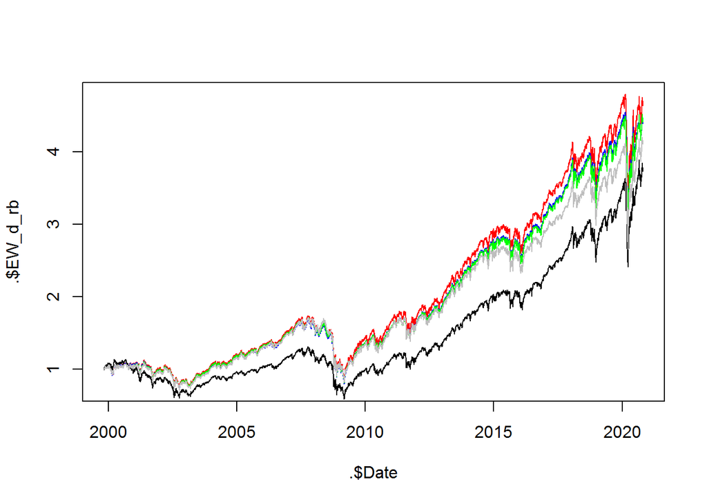

```r
# All result
all_cumret %>% {plot(.$Date, .$EW_d_rb, type='l', col = "red");
  points(.$Date, .$EW_m_rb, type='l', col = "blue");
  points(.$Date, .$EW_y_rb, type='l', col = "green");
  points(.$Date, .$SPY_cumret, type='l');
  points(.$Date, .$EW_no_rb, type='l', col = "gray")}
```

The red line (EW daily re-balance) is the best

### Metric

```r
# Return (done)

 # annualized return for EW (no re-balance)
all_cumret$EW_no_rb[length(all_cumret$EW_no_rb)] ** (250 / length(daily_ret$Date))
```

```
## [1] 1.069206
```

```r
 # annualized return for EW (daily re-balance)
prod(daily_ret$EW + 1) ** (250 / length(daily_ret$EW)) # 4.638940 annualized
```

```
## [1] 1.075405
```

```r
 # annualized return for EW (monthly re-balance)
all_cumret$EW_m_rb[length(all_cumret$EW_no_rb)] ** (250 / length(daily_ret$Date))
```

```
## [1] 1.072666
```

```r
 # annualized return for EW (yearly re-balance)
all_cumret$EW_y_rb[length(all_cumret$EW_no_rb)] ** (250 / length(daily_ret$Date))
```

```
## [1] 1.072878
```

```r
 # annualized return for SPY
prod(daily_ret$SPY + 1) ** (250 / length(daily_ret$Date))
```

```
## [1] 1.064508
```

We can see that the annualized return of EW daily re-balance (1.0754) and yearly re-balance (1.0728) are the best. The SPY return is the lowest

```r
# simplified Sharp ratio (done)

 # no re-balance
all_cumret$EW_no_rb[length(all_cumret$Date)] ** (250 / length(all_cumret$Date)) / sd(all_cumret$EW_no_rb_daily) / sqrt(250)
```

```
## [1] 5.680789
```

```r
 # daily re-balance
prod(daily_ret$EW + 1) ** (250 / length(daily_ret$EW)) / sd(daily_ret$EW) / sqrt(250)
```

```
## [1] 5.670242
```

```r
 # monthly re-balance
all_cumret$EW_m_rb[length(all_cumret$Date)] ** (250 / length(all_cumret$Date)) / sd(all_cumret$EW_m_rb_daily) / sqrt(250)
```

```
## [1] 5.675332
```

```r
 # yearly re-balance
all_cumret$EW_y_rb[length(all_cumret$Date)] ** (250 / length(all_cumret$Date)) / sd(all_cumret$EW_y_rb_daily) / sqrt(250)
```

```
## [1] 5.739384
```

```r
 # SPY
prod(daily_ret$SPY + 1) ** (250 / length(daily_ret$SPY)) / sd(daily_ret$SPY) / sqrt(250)
```

```
## [1] 5.376987
```

We can see that the EW yearly re-balance (5.7394) is the best in Sharp Ratio. The SPY Sharp Ratio is the lowest

```r
# Calculate the Max DD (done)

 # no re-balance
max_previous_no_rb <- no_rb_2
for (i in 22:32){
  for (a in 1:length(t(no_rb_2[1]))){
    max_previous_no_rb[a, i] <- max(no_rb_2[1:a, i])
  }
}
max_ddr_no_rb <- max_previous_no_rb
max_dd_no_rb <- max_previous_no_rb
max_ddr_no_rb[22:32] <- 1 - (no_rb_2[22:32] / max_previous_no_rb[22:32])
max_dd_no_rb[22:32] <- max_previous_no_rb[22:32] - no_rb_2[22:32]
```

```r
max_dd_no_rb2 <- max_dd_no_rb[ ,31:32]
max(max_dd_no_rb2[1]) # SPY
```

```
## [1] 11040763
```

```r
max(max_dd_no_rb2[2]) # EW
```

```
## [1] 13157032
```

The maximum DD of SPY is 11040763 (initial investment 9000000) The maximum DD of EW No re-balance is 13157032 (initial investment 9000000)

```r
 # monthly re-balance
pnl_mbl <- m_rb
s3 <- lag(pnl_mbl[2:21])
for(i in 2:10){
  pnl_mbl[paste0(colnames(pnl_mbl)[i], "_pnl")] <- (pnl_mbl[colnames(pnl_mbl[i])] - s3[colnames(s3[i-1])]) * s3[colnames(s3[i+9])]
}
for(i in 2:10){
  pnl_mbl[paste0(colnames(pnl_mbl)[i], "_adjmv")] <- 0
}
pnl_mbl[1, 42:50] <- pnl_mbl[1, 22:30]
pnl_mbl[2:length(t(pnl_mbl[1])), 42:50] <- pnl_mbl[2:length(t(pnl_mbl[1])), 33:41]
pnl_mbl[, 42:50] <- cumsum(pnl_mbl[, 42:50])
```

```r
max_previous_m_rb <- pnl_mbl[c(1, 42:50, 32, 31)]
select_m <- pnl_mbl[c(1, 42:50, 32, 31)]
for (i in 2:12){
  for (a in 1:length(t(select_m[1]))){
    max_previous_m_rb[a, i] <- max(select_m[1:a, i])
  }
}
max_ddr_m_rb <- max_previous_m_rb
max_dd_m_rb <- max_previous_m_rb

max_ddr_m_rb[2:12] <- 1 - (select_m[2:12] / max_previous_m_rb[2:12])
max_dd_m_rb[2:12] <- max_previous_m_rb[2:12] - select_m[2:12]
```

```r
max_dd_m_rb2 <- max_dd_m_rb[ ,11:12]
max(max_dd_m_rb2[2]) # SPY
```

```
## [1] 11040763
```

```r
max(max_dd_m_rb2[1]) # EW
```

```
## [1] 14957803
```

The maximum DD of EW monthly re-balance is 14957803 (initial investment 9000000)

```r
 # yearly re-balance
pnl_ybl <- y_rb
s4 <- lag(pnl_ybl[2:21])
for(i in 2:10){
  pnl_ybl[paste0(colnames(pnl_ybl)[i], "_pnl")] <- (pnl_ybl[colnames(pnl_ybl[i])] - s4[colnames(s4[i-1])]) * s4[colnames(s4[i+9])]
}
for(i in 2:10){
  pnl_ybl[paste0(colnames(pnl_ybl)[i], "_adjmv")] <- 0
}
pnl_ybl[1, 42:50] <- pnl_ybl[1, 22:30]
pnl_ybl[2:length(t(pnl_ybl[1])), 42:50] <- pnl_ybl[2:length(t(pnl_ybl[1])), 33:41]
pnl_ybl[, 42:50] <- cumsum(pnl_ybl[, 42:50])
```

```r
max_previous_y_rb <- pnl_ybl[c(1, 42:50, 32, 31)]
select_y <- pnl_ybl[c(1, 42:50, 32, 31)]
for (i in 2:12){
  for (a in 1:length(t(select_y[1]))){
    max_previous_y_rb[a, i] <- max(select_y[1:a, i])
  }
}
max_ddr_y_rb <- max_previous_y_rb
max_dd_y_rb <- max_previous_y_rb

max_ddr_y_rb[2:12] <- 1 - (select_y[2:12] / max_previous_y_rb[2:12])
max_dd_y_rb[2:12] <- max_previous_y_rb[2:12] - select_y[2:12]
```

```r
max_dd_y_rb2 <- max_dd_y_rb[ ,11:12]
max(max_dd_y_rb2[2]) # SPY
```

```
## [1] 11040763
```

```r
max(max_dd_y_rb2[1]) # EW
```

```
## [1] 14625109
```

The maximum DD of EW yearly re-balance is 14625109 (initial investment 9000000)

Overall, We can see that EW monthly re-balance strategy has the highest max DD

### Analyze

```r
# Rank all ETFs by its contribution to PnL over the entire period. (done)

 # No re-balance
pnl_rank_nbl <- no_rb_2[length(t(no_rb_2[1])),22:30][order(-no_rb_2[length(t(no_rb[1])),22:30])]
pnl_rank_nbl
```

| XLY_mv | XLV_mv | XLU_mv | XLB_mv | XLI_mv | XLP_mv | XLK_mv | XLF_mv | XLE_mv |
| --- | --- | --- | --- | --- | --- | --- | --- | --- |
| 6965278 | 5135974 | 4531585 | 4467278 | 4361374 | 4255209 | 3630487 | 1841202 | 1766429 |

```r
 # monthly re-balance
pnl_rank_mbl <- pnl_mbl[length(t(pnl_mbl[1])),42:50][order(-pnl_mbl[length(t(pnl_mbl[1])),42:50])]
pnl_rank_mbl
```

| XLK_adjmv | XLY_adjmv | XLV_adjmv | XLU_adjmv | XLI_adjmv | XLB_adjmv | XLP_adjmv | XLF_adjmv | XLE_adjmv |
| --- | --- | --- | --- | --- | --- | --- | --- | --- |
| 6282891 | 5998542 | 5068850 | 4818491 | 4659875 | 4476448 | 4449462 | 3154262 | 654103.5 |

```r
 # yearly re-balance
pnl_rank_ybl <- pnl_ybl[length(t(pnl_ybl[1])),42:50][order(-pnl_ybl[length(t(pnl_ybl[1])),42:50])]
pnl_rank_ybl
```

| XLK_adjmv | XLY_adjmv | XLV_adjmv | XLU_adjmv | XLI_adjmv | XLB_adjmv | XLP_adjmv | XLF_adjmv | XLE_adjmv |
| --- | --- | --- | --- | --- | --- | --- | --- | --- |
| 6805910 | 6138559 | 5022733 | 4644803 | 4517659 | 4425967 | 4366839 | 3067255 | 738255.2 |

The ranking of each ETFs among 3 strategies can be seen in these 3 tables

```r
# Rank all ETFs by its risk (max. draw down %) over the entire period (done)

  # No re-balance
max_ddr_no_rb2 <- max_ddr_no_rb[1, 22:30]
for(i in 22:30){
  max_ddr_no_rb2[i-21] <- max(max_ddr_no_rb[i])
}
risk_rank_no_rb <- max_ddr_no_rb2[order(-max_ddr_no_rb2[1:9])]
#max_ddr_no_rb2
risk_rank_no_rb
```

| XLF_mv | XLK_mv | XLE_mv | XLI_mv | XLB_mv | XLY_mv | XLU_mv | XLV_mv | XLP_mv |
| --- | --- | --- | --- | --- | --- | --- | --- | --- |
| 0.8271618 | 0.8204641 | 0.7126151 | 0.6227506 | 0.5982801 | 0.5904681 | 0.519608 | 0.3916875 | 0.3589225 |

```r
 # Monthly re-balance
max_ddr_m_rb2 <- max_ddr_m_rb[1, 2:10]
for(i in 2:10){
  max_ddr_m_rb2[i-1] <- max(max_ddr_m_rb[i])
}
risk_rank_m_rb <- max_ddr_m_rb2[order(-max_ddr_m_rb2[1:9])]
risk_rank_m_rb
```

| XLF_adjmv | XLK_adjmv | XLE_adjmv | XLY_adjmv | XLI_adjmv | XLU_adjmv | XLB_adjmv | XLV_adjmv | XLP_adjmv |
| --- | --- | --- | --- | --- | --- | --- | --- | --- |
| 1.194895 | 1.083355 | 0.9855534 | 0.7028022 | 0.6319722 | 0.519193 | 0.4728312 | 0.3977594 | 0.3305506 |

```r
 # yearly re-balance
max_ddr_y_rb2 <- max_ddr_y_rb[1, 2:10]
for(i in 2:10){
  max_ddr_y_rb2[i-1] <- max(max_ddr_y_rb[i])
}
risk_rank_y_rb <- max_ddr_y_rb2[order(-max_ddr_y_rb2[1:9])]
risk_rank_y_rb
```

| XLF_adjmv | XLK_adjmv | XLE_adjmv | XLY_adjmv | XLI_adjmv | XLB_adjmv | XLU_adjmv | XLV_adjmv | XLP_adjmv |
| --- | --- | --- | --- | --- | --- | --- | --- | --- |
| 0.9997087 | 0.9480171 | 0.9339188 | 0.7145957 | 0.62306 | 0.5070682 | 0.4671371 | 0.4455577 | 0.3426352 |

The ranking of each ETFs among 3 strategies can be seen in these 3 tables

# Momentum Strategy

- Empirically, there appears to be certain “inertia” in stock returns known as the momentum effect, whereby future returns are positively correlated with past returns.
- We use a price momentum here. At any point, we rank the ETFs according to following.
  - At row `i`, momentum is `( price[i-21] - price[i-252] ) / price[i-252] - ( price[i-1] - price[i-21] ) / price[i-21]`
- Set to re-balance every month
  - Long the top 4 stocks with equal weights, or
  - Long the top 2 stocks and Short bottom 2 stocks with equal weights.

```r
daily_price <- tibble(Date = dd[[1]]$timestamp)
for (ii in 1:len_tickers) {
  if (all_tickers[ii] == 'SPY') { next }
  daily_price[all_tickers[ii]] <- dd[[ii]]$adjusted_close
}

# Assume monthly re-balance
month_mom <- daily_price[rebal_days_m, ]

for (r in rebal_days_m) {

  mm <- numeric(len_invest)

  # Generate momentum

  for (ii in 1:len_invest) {
     tt <- invest_tickers[ii]

     # Use 1 if look-back period is not enough.
     r_prev_d <- if_else(r > 1, r - 1, 1)
     r_prev_m <- if_else(r > 21, r - 21, 1)
     r_prev_y <- if_else(r > 252, r - 252, 1)

     x <- (daily_price[r_prev_m,tt] - daily_price[r_prev_y,tt] ) / daily_price[r_prev_y,tt] - ( daily_price[r_prev_d,tt] - daily_price[r_prev_m,tt] ) / daily_price[r_prev_m,tt]
     mm[ii] <- as.numeric(x)
     month_mom[which(rebal_days_m == r), ii+1] <- mm[ii]
  }
  # TODO: rank and allocation.

  # run one cycle first, then remove break
  #break
}
```

```r
# create the rank column for the momentum strategies
month_mom["rank_1"] <- 0
month_mom["rank_2"] <- 0
month_mom["rank_3"] <- 0
month_mom["rank_4"] <- 0
month_mom["rank_8"] <- 0
month_mom["rank_9"] <- 0
for(i in 1:length(t(month_mom[1]))){
  month_mom[i, 11:14] <- as.list(order(month_mom[i, 2:10], decreasing=TRUE)[1:4])
  month_mom[i, 15:16] <- as.list(order(month_mom[i, 2:10], decreasing=TRUE)[8:9])
}
```

### TODO

For each of Momentum strategy: - Long the top 4 stocks with equal weights, or

```r
mom_m_rb <- m_rb

for(i in 12:length(rebal_days_m)){
  if(i < length(rebal_days_m)){


  # allocate the new number of shares at re-balance date
    rb_mv <- sum(mom_m_rb[rebal_days_m[i], 2:10] * mom_m_rb[rebal_days_m[i]-1, 12:20]) / 4

    mom_m_rb[rebal_days_m[i], 12:20] <- 0

    ticker <- invest_tickers[as.numeric(month_mom[i, 11:14])]

    mom_m_rb[rebal_days_m[i], paste0(ticker, "_mv")] <- rb_mv

    mom_m_rb[rebal_days_m[i], paste0(ticker, "_num")] <- round(rb_mv / mom_m_rb[rebal_days_m[i], ticker])
    mom_m_rb[rebal_days_m[i]:(rebal_days_m[i+1]-1), 12:20] <- mom_m_rb[rebal_days_m[i], 12:20]

    mom_m_rb[rebal_days_m[i]:(rebal_days_m[i+1]-1), 22:30] <- mom_m_rb[rebal_days_m[i]:(rebal_days_m[i+1]-1), 2:10] * mom_m_rb[rebal_days_m[i]:(rebal_days_m[i+1]-1), 12:20]

    for(ii in rebal_days_m[i]:(rebal_days_m[i+1]-1)){
      mom_m_rb$EW_mv[ii] <- sum(mom_m_rb[ii, 22:30])
    }
  }

  else{
    rb_mv <- sum(mom_m_rb[rebal_days_m[i], 2:10] * mom_m_rb[rebal_days_m[i]-1, 12:20]) / 4

    mom_m_rb[rebal_days_m[i], 12:20] <- 0
    mom_m_rb[rebal_days_m[i], 22:30] <- 0

    ticker <- invest_tickers[as.numeric(month_mom[i, 11:14])]

    mom_m_rb[rebal_days_m[i], paste0(ticker, "_mv")] <- rb_mv

    mom_m_rb[rebal_days_m[i], paste0(ticker, "_num")] <- round(rb_mv / mom_m_rb[rebal_days_m[i], ticker])

    mom_m_rb$EW_mv[rebal_days_m[i]] <- rb_mv * 4
  }
}
```

- Long the top 2 stocks and Short bottom 2 stocks with equal weights.

```r
mom2_m_rb <- m_rb

for(i in 12:length(rebal_days_m)){
  if(i < length(rebal_days_m)){

    rb_mv <-  (mom2_m_rb$EW_mv[rebal_days_m[i]-1] + sum((mom2_m_rb[rebal_days_m[i], 2:10] - mom2_m_rb[rebal_days_m[i]-1, 2:10]) * mom2_m_rb[rebal_days_m[i]-1, 12:20])) / 4

    mom2_m_rb[rebal_days_m[i], 12:20] <- 0
    mom2_m_rb[rebal_days_m[i], 22:30] <- 0

    ticker_long <- invest_tickers[as.numeric(month_mom[i, 11:12])]
    ticker_short <- invest_tickers[as.numeric(month_mom[i, 15:16])]

    mom2_m_rb[rebal_days_m[i], paste0(ticker_long, "_mv")] <- rb_mv
    mom2_m_rb[rebal_days_m[i], paste0(ticker_short, "_mv")] <- rb_mv

    mom2_m_rb[rebal_days_m[i], paste0(ticker_long, "_num")] <- round(rb_mv / mom2_m_rb[rebal_days_m[i], ticker_long])

    mom2_m_rb[rebal_days_m[i], paste0(ticker_short, "_num")] <- -round(rb_mv / mom2_m_rb[rebal_days_m[i], ticker_short])

    mom2_m_rb[rebal_days_m[i]:(rebal_days_m[i+1]-1), 12:20] <- mom2_m_rb[rebal_days_m[i], 12:20]

    for(ii in rebal_days_m[i]:(rebal_days_m[i+1]-2)){

      mom2_m_rb[ii+1, 22:30] <- mom2_m_rb[ii, 22:30] + (mom2_m_rb[ii+1, 2:10] - mom2_m_rb[ii, 2:10]) * mom2_m_rb[ii, 12:20]

      mom2_m_rb$EW_mv[ii] <- sum(mom2_m_rb[ii, 22:30])
      mom2_m_rb$EW_mv[ii+1] <- sum(mom2_m_rb[ii+1, 22:30])
    }
  }

  else{

    rb_mv <-  (mom2_m_rb$EW_mv[rebal_days_m[i]-1] + sum((mom2_m_rb[rebal_days_m[i], 2:10] - mom2_m_rb[rebal_days_m[i]-1, 2:10]) * mom2_m_rb[rebal_days_m[i]-1, 12:20])) / 4

    mom2_m_rb[rebal_days_m[i], 12:20] <- 0
    mom2_m_rb[rebal_days_m[i], 22:30] <- 0

    ticker <- invest_tickers[as.numeric(month_mom[i, 11:14])]

    mom2_m_rb[rebal_days_m[i], paste0(ticker, "_mv")] <- rb_mv

    mom2_m_rb[rebal_days_m[i], paste0(ticker, "_num")] <- round(rb_mv / mom2_m_rb[rebal_days_m[i], ticker])

    mom2_m_rb$EW_mv[rebal_days_m[i]] <- rb_mv * 4
  }
}
```

Finish the strategy model

```r
 # we should calculate the adjust mv of each ETFs based on daily PnL
mom_pnl <- mom_m_rb
ss1 <- lag(mom_pnl[2:21])
for(i in 2:10){
  mom_pnl[paste0(colnames(mom_pnl)[i], "_pnl")] <- (mom_pnl[colnames(mom_pnl[i])] - ss1[colnames(ss1[i-1])]) * ss1[colnames(ss1[i+9])]
}
for(i in 2:10){
  mom_pnl[paste0(colnames(mom_pnl)[i], "_adjmv")] <- 0
}
mom_pnl[1, 42:50] <- mom_pnl[1, 22:30]
mom_pnl[2:length(t(mom_pnl[1])), 42:50] <- mom_pnl[2:length(t(mom_pnl[1])), 33:41]
mom_pnl[, 42:50] <- cumsum(mom_pnl[, 42:50])
```

```r
mom2_pnl <- mom2_m_rb
ss2 <- lag(mom2_pnl[2:21])
for(i in 2:10){
  mom2_pnl[paste0(colnames(mom2_pnl)[i], "_pnl")] <- (mom2_pnl[colnames(mom2_pnl[i])] - ss2[colnames(ss2[i-1])]) * ss2[colnames(ss2[i+9])]
}
for(i in 2:10){
  mom2_pnl[paste0(colnames(mom2_pnl)[i], "_adjmv")] <- 0
}
mom2_pnl[1, 42:50] <- mom2_pnl[1, 22:30]
mom2_pnl[2:length(t(mom2_pnl[1])), 42:50] <- mom2_pnl[2:length(t(mom2_pnl[1])), 33:41]
mom2_pnl[, 42:50] <- cumsum(mom2_pnl[, 42:50])
```

### Calculate Strategy return (plot & annualized return)

```r
# Final result

all_cumret2 <- mom_pnl[c(1, 32)][2:length(mom_pnl$Date), ]
colnames(all_cumret2)[2] <- "EW_mom_lo4"
all_cumret2[2] <- mom_pnl$EW_mv[2:length(mom_pnl$Date)] / 8999959
all_cumret2 <- mutate(all_cumret2, EW_mom_lo2sh2 = mom2_pnl$EW_mv[2:length(mom2_pnl$Date)] / 8999959, SPY_cumret = daily_ret$SPY_cumret)
```

```r
ss3 <- lag(all_cumret2[2:4])
ss3[1, ] <- 1
for(i in 2:4){
  all_cumret2[paste0(colnames(all_cumret2)[i], "_daily")] <- all_cumret2[i] / ss3[i-1] - 1
}
```

After this step, we can view the final performance (cumulative return) for the 2 strategies and the SPY

### Relative Performance between Momemtum Strategy and SPY

We plot the 2+1 cumulative return

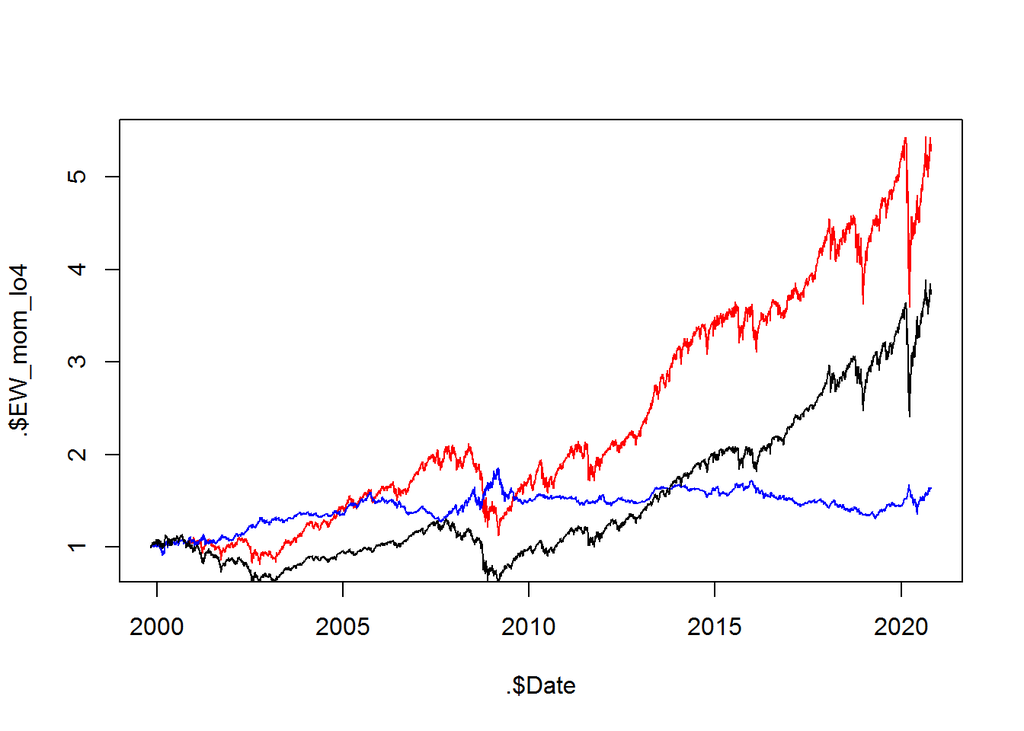

```r
# All result
all_cumret2 %>% {plot(.$Date, .$EW_mom_lo4, type='l', col = "red");
  points(.$Date, .$EW_mom_lo2sh2, type='l', col = "blue");
  points(.$Date, .$SPY_cumret, type='l')}
```

The red line (Long top 4) strategy is the best for earning return. The blue line is like a hedging line (very low change)

### Annualized return

```r
# Return (done)

 # annualized return for Long Top 4 strategy
all_cumret2$EW_mom_lo4[length(all_cumret2$EW_mom_lo4)] ** (250 / length(all_cumret2$Date))
```

```
## [1] 1.082036
```

```r
 # annualized return for Long Top 2 short last 2 strategy
all_cumret2$EW_mom_lo2sh2[length(all_cumret2$EW_mom_lo2sh2)] ** (250 / length(all_cumret2$Date))
```

```
## [1] 1.023748
```

```r
 # annualized return for SPY
all_cumret2$SPY_cumret[length(all_cumret2$SPY_cumret)] ** (250 / length(all_cumret2$Date))
```

```
## [1] 1.064508
```

The long top 4 strategy has the highest annualized return while Long top 2 Short last 2 has the lowest

### Sharp ratio

```r
# simplified Sharp ratio (done)

 # Long Top 4 strategy
all_cumret2$EW_mom_lo4[length(all_cumret2$Date)] ** (250 / length(all_cumret2$Date)) / sd(all_cumret2$EW_mom_lo4_daily) / sqrt(250)
```

```
## [1] 5.761625
```

```r
 # Long Top 2 short last 2 strategy
all_cumret2$EW_mom_lo2sh2[length(all_cumret2$Date)] ** (250 / length(all_cumret2$Date)) / sd(all_cumret2$EW_mom_lo2sh2_daily) / sqrt(250)
```

```
## [1] 10.1438
```

```r
 # SPY
all_cumret2$SPY_cumret[length(all_cumret2$Date)] ** (250 / length(all_cumret2$Date)) / sd(all_cumret2$SPY_cumret_daily) / sqrt(250)
```

```
## [1] 5.376987
```

The Long Top 2 Short Last 2 Strategy has the highest sharp ratio

### Max DD

```r
# Long Top 4 strategy
max_previous_mom <- mom_pnl[c(1, 42:50, 32, 31)]
select_mom <- mom_pnl[c(1, 42:50, 32, 31)]
for (i in 2:12){
  for (a in 1:length(t(select_mom[1]))){
    max_previous_mom[a, i] <- max(select_mom[1:a, i])
  }
}
max_ddr_mom <- max_previous_mom
max_dd_mom <- max_previous_mom

max_ddr_mom[2:12] <- 1 - (select_mom[2:12] / max_previous_mom[2:12])
max_dd_mom[2:12] <- max_previous_mom[2:12] - select_mom[2:12]
```

```r
max_dd_mom_rank <- max_dd_mom[ ,11:12]
max(max_dd_mom_rank[2]) # SPY
```

```
## [1] 11040763
```

```r
max(max_dd_mom_rank[1]) # Long Top 4 strategy
```

```
## [1] 16466630
```

The maximum DD of Long Top 4 strategy is 16466630 (initial investment 9000000)

```r
# Long Top 2 Short Last 2 strategy
max_previous_mom2 <- mom2_pnl[c(1, 42:50, 32, 31)]
select_mom2 <- mom2_pnl[c(1, 42:50, 32, 31)]
for (i in 2:12){
  for (a in 1:length(t(select_mom2[1]))){
    max_previous_mom2[a, i] <- max(select_mom2[1:a, i])
  }
}
max_ddr_mom2 <- max_previous_mom2
max_dd_mom2 <- max_previous_mom2

max_ddr_mom2[2:12] <- 1 - (select_mom2[2:12] / max_previous_mom2[2:12])
max_dd_mom2[2:12] <- max_previous_mom2[2:12] - select_mom2[2:12]
```

```r
max_dd_mom2_rank <- max_dd_mom2[ ,11:12]
max(max_dd_mom2_rank[2]) # SPY
```

```
## [1] 11040763
```

```r
max(max_dd_mom2_rank[1]) # Long Top 2 Short Last 2 strategy
```

```
## [1] 4982219
```

The maximum DD of Long Top 2 Short Last 2 strategy is 4982219 (initial investment 9000000)

### PnL rank

The ranking of each ETFs among 2 strategies can be seen in these 2 tables

```r
# Rank all ETFs by its contribution to PnL over the entire period.

 # Long Top 4 strategy
pnl_rank_mom <- mom_pnl[length(t(mom_pnl[1])),42:50][order(-mom_pnl[length(t(mom_pnl[1])),42:50])]
pnl_rank_mom
```

| XLK_adjmv | XLY_adjmv | XLI_adjmv | XLV_adjmv | XLE_adjmv | XLP_adjmv | XLU_adjmv | XLB_adjmv | XLF_adjmv |
| --- | --- | --- | --- | --- | --- | --- | --- | --- |
| 10770910 | 9800484 | 7520266 | 5443684 | 3888730 | 3733768 | 2900144 | 2423626 | 1053117 |

```r
 # Long Top 2 Short Last 2 strategy
pnl_rank_mom2 <- mom2_pnl[length(t(mom2_pnl[1])),42:50][order(-mom2_pnl[length(t(mom2_pnl[1])),42:50])]
pnl_rank_mom2
```

| XLF_adjmv | XLK_adjmv | XLE_adjmv | XLY_adjmv | XLV_adjmv | XLI_adjmv | XLB_adjmv | XLP_adjmv | XLU_adjmv |
| --- | --- | --- | --- | --- | --- | --- | --- | --- |
| 4610737 | 4132308 | 3106520 | 1895348 | 1174087 | 1164500 | -144655.1 | -164538.6 | -1003897 |

### max DD% rank

The ranking of each ETFs among 2 strategies can be seen in these 2 tables

```r
# Rank all ETFs by its risk (max. draw down %) over the entire period (done)

 # Long Top 4 strategy
max_ddr_mom_res <- max_ddr_mom[1, 2:10]
for(i in 2:10){
  max_ddr_mom_res[i-1] <- max(max_ddr_mom[i])
}
risk_rank_mom <- max_ddr_mom_res[order(-max_ddr_mom_res[1:9])]
risk_rank_mom
```

| XLY_adjmv | XLP_adjmv | XLF_adjmv | XLV_adjmv | XLB_adjmv | XLU_adjmv | XLK_adjmv | XLI_adjmv | XLE_adjmv |
| --- | --- | --- | --- | --- | --- | --- | --- | --- |
| 1.125095 | 1.123366 | 1.110109 | 1.014827 | 0.9104143 | 0.8533091 | 0.7922587 | 0.6755385 | 0.5288756 |

```r
 # Long Top 2 Short Last 2 strategy
max_ddr_mom_res2 <- max_ddr_mom2[1, 2:10]
for(i in 2:10){
  max_ddr_mom_res2[i-1] <- max(max_ddr_mom2[i])
}
risk_rank_mom2 <- max_ddr_mom_res2[order(-max_ddr_mom_res2[1:9])]
risk_rank_mom2
```

| XLB_adjmv | XLY_adjmv | XLP_adjmv | XLU_adjmv | XLV_adjmv | XLI_adjmv | XLE_adjmv | XLF_adjmv | XLK_adjmv |
| --- | --- | --- | --- | --- | --- | --- | --- | --- |
| 2.382571 | 1.908641 | 1.611489 | 1.491777 | 1.004874 | 0.7444485 | 0.7083939 | 0.5907248 | 0.5535652 |